# Machine Learning Exercise 1 - Linear Regression

## Linear regression with multiple variables

From now on, you will use the second dataset, i.e., ex1data2.txt. This is a housing price dataset with 2 variables (size of the house in square feet and number of bedrooms) and a target (price of the house). You are asked to use the techniques already applied to analyze that data set.

```python
data2 = pd.read_csv('ex1data2.txt', header=None, names=['Size', 'Bedrooms', 'Price'])
data2.head()
```

|  | Size | Bedrooms | Price |
| --- | --- | --- | --- |
| 0 | 2104 | 3 | 399900 |
| 1 | 1600 | 3 | 329900 |
| 2 | 2400 | 3 | 369000 |
| 3 | 1416 | 2 | 232000 |
| 4 | 3000 | 4 | 539900 |

For this task we add another pre-processing step - normalizing the features.

Notice that the scale of the values for each feature is vastly large. A house will typically have 2-5 bedrooms, but may have anywhere from hundreds to thousands of square feet. If we use the features as they are in the dataset, the 'size' feature would too much wheighted and would end up dwarfing any contributions from the 'number of bedrooms' feature. To fix this, we need to do something called 'feature normalization'. That is, we need to adjust the scale of the features to level the playing field. One way to do this is by subtracting from each value in a feature the mean of that feature, and then dividing by the standard deviation.

```python
data2 = (data2 - data2.mean()) / data2.std()
data2.head()
```

|  | Size | Bedrooms | Price |
| --- | --- | --- | --- |
| 0 | 0.130010 | -0.223675 | 0.475747 |
| 1 | -0.504190 | -0.223675 | -0.084074 |
| 2 | 0.502476 | -0.223675 | 0.228626 |
| 3 | -0.735723 | -1.537767 | -0.867025 |
| 4 | 1.257476 | 1.090417 | 1.595389 |

Given that you were asked to implement both cost function and gradient descent using matrix operations, your previously implementations will work just fine in the multivariate dataset. Hence, you need now insert the 'ones' column as before and separate the X's and the y's.

Conduct the rest of this exercise by repeating the experiments conducted in the simple linear dataset...

```python
data2.insert(0, 'beta zero', 1)
data2.head()
```

|  | beta zero | Size | Bedrooms | Price |
| --- | --- | --- | --- | --- |
| 0 | 1 | 0.130010 | -0.223675 | 0.475747 |
| 1 | 1 | -0.504190 | -0.223675 | -0.084074 |
| 2 | 1 | 0.502476 | -0.223675 | 0.228626 |
| 3 | 1 | -0.735723 | -1.537767 | -0.867025 |
| 4 | 1 | 1.257476 | 1.090417 | 1.595389 |

```python
# set X (training data) and y (target variable)
cols2 = data2.shape[1]
X2 = data2.iloc[:,0:cols]
y2 = data2.iloc[:,cols:cols+1]
```

```python
X2.head()
```

|  | beta zero | Size |
| --- | --- | --- |
| 0 | 1 | 0.130010 |
| 1 | 1 | -0.504190 |
| 2 | 1 | 0.502476 |
| 3 | 1 | -0.735723 |
| 4 | 1 | 1.257476 |

```python
y2.head()
```

|  | Price |
| --- | --- |
| 0 | 0.475747 |
| 1 | -0.084074 |
| 2 | 0.228626 |
| 3 | -0.867025 |
| 4 | 1.595389 |

```python
#X2 = np.matrix(X2.values)
#y2 = np.matrix(y2.values)
beta2 = np.matrix(np.array([0,0,0]))

X2.shape, y2.shape, beta2.shape
```

```
((47, 2), (47, 1), (1, 3))
```

```python
compute_cost(X2, y2, beta2)
```

[output not shown]

```python
def gradient_descent56(X, y, theta, alpha, iters):

    cost = np.zeros(iters)
    e = compute_cost(X, y, theta)
    m = len(X)

    for j in range(iters):
        predicted_values = np.dot(X, theta.transpose())
        theta = theta - ( (alpha / m) * np.dot((predicted_values - y).transpose(), X) )

        cost[j] = compute_cost(X, y, theta)
        '''
        if e-cost[j-1] <= alpha:
            print('Iteration: ',j)
            return theta, cost
'''
    return theta, cost
```

```python
alpha2 = 0.01
iters2 = 1500
```

Now let's run the gradient descent algorithm to fit our parameters theta to the training set.

```python
g2, cost2 = gradient_descent56(X2, y2, beta2, alpha2, iters2)
g2
```

[output not shown]

```python
compute_cost(X2, y2, g2)
```

```
0.13068670606095903
```

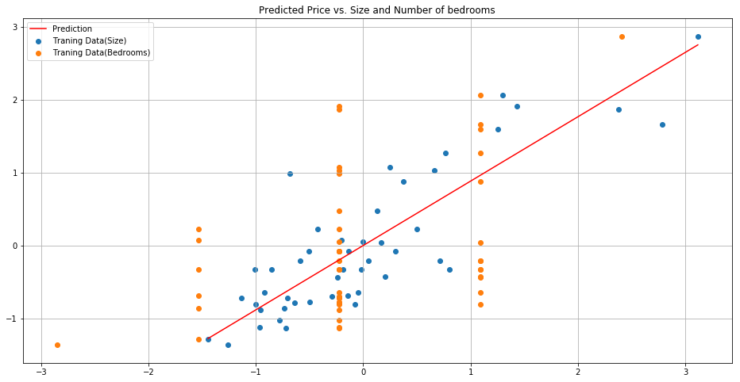

```python
x = np.linspace(data2.Size.min(), data2.Size.max(), 100)
f = g2[0, 0] + (g2[0, 1] * x)

fig, ax = plt.subplots(figsize=(16,8))
ax.plot(x, f, 'r', label='Prediction')
ax.scatter(data2.Size, data2.Price, label='Traning Data(Size)')
ax.scatter(data2.Bedrooms, data2.Price, label='Traning Data(Bedrooms)')
ax.legend(loc='best')
ax.set_title('Predicted Price vs. Size and Number of bedrooms')

ax.grid(True)
```

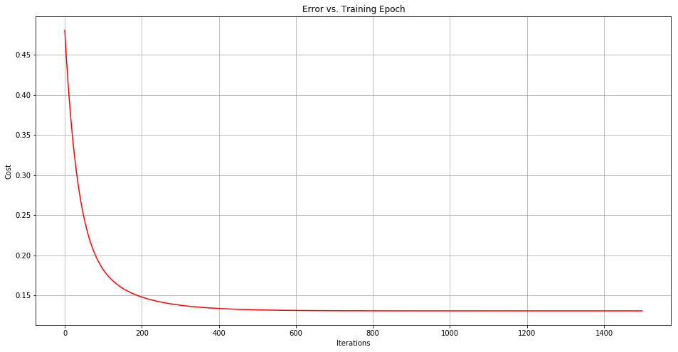

```python
fig, ax = plt.subplots(figsize=(16,8))
ax.plot(np.arange(iters2), cost2, 'r')
ax.set_xlabel('Iterations')
ax.set_ylabel('Cost')
ax.set_title('Error vs. Training Epoch')
ax.grid(True)
```